# **Foundations of Machine Learning Frameworks CSCN8010**

# Prashansa Rathod 8993410

# Harsh Joshi 8952840

### *Introduction*

Diabetic Retinopathy (DR) is one of the leading causes of blindness worldwide, especially among adults with diabetes. It occurs due to damage to the blood vessels in the retina caused by prolonged high blood sugar levels. Early detection and treatment of DR are crucial to prevent vision loss. However, diagnosing DR typically requires skilled ophthalmologists and specialized equipment, which may not be accessible in remote or underserved regions.

With the advent of deep learning and computer vision, automated solutions for DR detection have gained attention. The *Diabetic Retinopathy Resized Dataset*, available on Kaggle, provides high-resolution retinal images labeled with different levels of DR severity, enabling researchers to train machine learning models for automated diagnosis. This project leverages the dataset to develop a robust AI-based system for detecting and classifying diabetic retinopathy, potentially supporting early diagnosis and improving patient outcomes.

Reference to the datafile https://www.kaggle.com/datasets/tanlikesmath/diabetic-retinopathy-resized/data

Other References :

- https://en.wikipedia.org/wiki/Diabetic_retinopathy
- https://www.kaggle.com/c/diabetic-retinopathy-detection
- chatgpt

### *Use Cases*

1. *Automated Screening Tool*:
   - Use the trained model as a screening tool for early detection of diabetic retinopathy, reducing the workload on ophthalmologists and enabling early interventions.
2. *Telemedicine Integration*:
   - Deploy the model in telemedicine platforms for remote diagnosis, especially in rural or underserved areas where access to specialists is limited.
3. *Clinical Decision Support*:
   - Assist medical professionals by providing a second opinion or initial screening of retinal images to prioritize patients for further examination.
4. *Medical Education and Training*:
   - Use the model and dataset to train students and researchers in medical imaging, focusing on how AI can enhance healthcare diagnostics.
5. *Healthcare Research*:
   - Utilize the model to analyze patterns in diabetic retinopathy progression, contributing to research on the causes and prevention of DR-related blindness.
6. *Real-Time Screening Applications*:
   - Incorporate the trained model into mobile or handheld devices for real-time DR screening during routine check-ups.
7. *Explainable AI in Medicine*:
   - Implement Grad-CAM or other visualization techniques to highlight regions of the retina that influence predictions, improving trust and usability for clinicians.
- Importing necessary libraries

```python
# Import necessary libraries
import os
import pandas as pd
import numpy as np
from tensorflow.keras.applications import VGG16
from tensorflow.keras.models import Model
from tensorflow.keras.layers import Dense, Flatten, Dropout
from tensorflow.keras.preprocessing.image import ImageDataGenerator
from tensorflow.keras.optimizers import Adam
from sklearn.model_selection import train_test_split
import matplotlib.pyplot as plt
```

- Load the Dataset

```python
# Define paths
base_dir = '../db'  # Replace with your actual path
train_dir = os.path.join(base_dir, 'resized_train')
labels_file = os.path.join(base_dir, 'trainLabels.csv')

# Load the labels
labels_df = pd.read_csv(labels_file)
labels_df['image'] = labels_df['image'] + '.jpg'  # Add the ".jpg" extension if missing
labels_df['binary_label'] = labels_df['level'].apply(lambda x: 1 if x > 0 else 0)  # Binary classification
```

- Creating Diretories

```python
# Define base output directory
base_output_dir = 'dataset_split'

# Subdirectory paths for train, validation, and test
train_output = os.path.join(base_output_dir, 'train')
val_output = os.path.join(base_output_dir, 'validation')
test_output = os.path.join(base_output_dir, 'test')

# Create class-specific subdirectories for each split
for split in [train_output, val_output, test_output]:
    os.makedirs(os.path.join(split, 'class_0'), exist_ok=True)
    os.makedirs(os.path.join(split, 'class_1'), exist_ok=True)

print("Subdirectories created successfully.")
```

```
Subdirectories created successfully.
```

```python
# Normalize filenames in train_df, val_df, and test_df
train_df['image'] = train_df['image'].str.lower().str.strip()
val_df['image'] = val_df['image'].str.lower().str.strip()
test_df['image'] = test_df['image'].str.lower().str.strip()
```

```python
dataset_dir = '../db/resized_train'
# List files in the resized_train directory
image_files = os.listdir(dataset_dir)  # Ensure this is the correct dataset directory
print(f"Total files in {dataset_dir}: {len(image_files)}")
print("Examples of files in resized_train:", image_files[:10])

# Display a few filenames from the train DataFrame
print("Examples of filenames in train_df:")
print(train_df['image'].head(10))
```

```
Total files in ../db/resized_train: 35126
Examples of files in resized_train: ['10003_left.jpeg', '10003_right.jpeg', '10007_left.jpeg', '10007_right.jpeg', '10009_left.jpeg', '10009_right.jpeg', '1000_left.jpeg', '1000_right.jpeg', '10010_left.jpeg', '10010_right.jpeg']
Examples of filenames in train_df:
29855    37758_right.jpg
8624      10827_left.jpg
24777    31333_right.jpg
11146     13993_left.jpg
12002     15051_left.jpg
14387    18054_right.jpg
12649    15867_right.jpg
21394     26944_left.jpg
30600     38688_left.jpg
22835    28820_right.jpg
Name: image, dtype: object
```

```python
# Add `_left` or `_right` and `.jpeg` extension if needed
train_df['image'] = train_df['image'] + '.jpeg'
val_df['image'] = val_df['image'] + '.jpeg'
test_df['image'] = test_df['image'] + '.jpeg'

# Ensure all filenames are lowercase
train_df['image'] = train_df['image'].str.lower()
val_df['image'] = val_df['image'].str.lower()
test_df['image'] = test_df['image'].str.lower()

# Normalize filenames in the directory
image_files = [f.lower() for f in image_files]
```

```python
import pandas as pd

# Load the labels CSV
labels_file = '../db/trainLabels.csv'
labels_df = pd.read_csv(labels_file)
print("Columns in labels_df:", labels_df.columns)

# Add file extension and binary label
labels_df['image'] = labels_df['image'] + '.jpeg'  # Add correct file extension
labels_df['binary_label'] = labels_df['level'].apply(lambda x: 1 if x > 0 else 0)  # Binary classification
print("Sample data from labels_df:")
print(labels_df.head())
```

```
Columns in labels_df: Index(['image', 'level'], dtype='object')
Sample data from labels_df:
           image  level  binary_label
0   10_left.jpeg      0             0
1  10_right.jpeg      0             0
2   13_left.jpeg      0             0
3  13_right.jpeg      0             0
4   15_left.jpeg      1             1
```

```python
from sklearn.model_selection import train_test_split

# Split into train, validation, and test
train_df, temp_df = train_test_split(
    labels_df, test_size=0.3, stratify=labels_df['binary_label'], random_state=42
)
val_df, test_df = train_test_split(
    temp_df, test_size=0.333, stratify=temp_df['binary_label'], random_state=42
)

print(f"Training samples: {len(train_df)}")
print(f"Validation samples: {len(val_df)}")
print(f"Test samples: {len(test_df)}")
```

```
Training samples: 24588
Validation samples: 7028
Test samples: 3510
```

- Split the dataset into classes

```python
# Function to count files in each directory
def count_images(directory):
    for class_dir in ['class_0', 'class_1']:
        class_path = os.path.join(directory, class_dir)
        print(f"{class_dir} in {directory}: {len(os.listdir(class_path))} images")

# Verify the structure
print("Train directory:")
count_images('dataset_split/train')

print("Validation directory:")
count_images('dataset_split/validation')

print("Test directory:")
count_images('dataset_split/test')
```

```
Train directory:
class_0 in dataset_split/train: 18067 images
class_1 in dataset_split/train: 6521 images
Validation directory:
class_0 in dataset_split/validation: 5164 images
class_1 in dataset_split/validation: 1864 images
Test directory:
class_0 in dataset_split/test: 2579 images
class_1 in dataset_split/test: 931 images
```

```python
from shutil import copy2
from tqdm import tqdm

# Function to move files
def move_files(dataframe, output_dir):
    for _, row in tqdm(dataframe.iterrows(), total=len(dataframe)):
        src = os.path.join(dataset_dir, row['image'])  # Source file path
        dst = os.path.join(output_dir, f'class_{row["binary_label"]}', row['image'])  # Destination path
        if os.path.exists(src):
            copy2(src, dst)
        else:
            print(f"File not found: {src}")

# Move files for each split
print("Copying training images...")
move_files(train_df, os.path.join(base_output_dir, 'train'))

print("Copying validation images...")
move_files(val_df, os.path.join(base_output_dir, 'validation'))

print("Copying test images...")
move_files(test_df, os.path.join(base_output_dir, 'test'))

print("All files moved.")
```

```
Copying training images...
```

```
Copying validation images...
```

```
Copying test images...
```

```
All files moved.
```

# Performing EDA

```python
import pandas as pd
import matplotlib.pyplot as plt
import seaborn as sns
import os
from PIL import Image
```

```python
# Load the labels CSV
labels_file = '../db/trainLabels.csv'
labels_df = pd.read_csv(labels_file)

# Add a binary label for retinopathy vs no retinopathy
labels_df['binary_label'] = labels_df['level'].apply(lambda x: 1 if x > 0 else 0)

# Display basic stats
print("Dataset Overview:")
print(labels_df.head())
print("\nClass Distribution:")
print(labels_df['binary_label'].value_counts())
```

```
Dataset Overview:
      image  level  binary_label
0   10_left      0             0
1  10_right      0             0
2   13_left      0             0
3  13_right      0             0
4   15_left      1             1

Class Distribution:
binary_label
0    25810
1     9316
Name: count, dtype: int64
```

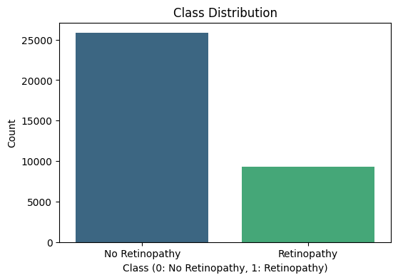

```python
# Class distribution
plt.figure(figsize=(6, 4))
sns.countplot(x='binary_label', data=labels_df, palette='viridis')
plt.title('Class Distribution')
plt.xlabel('Class (0: No Retinopathy, 1: Retinopathy)')
plt.ylabel('Count')
plt.xticks(ticks=[0, 1], labels=['No Retinopathy', 'Retinopathy'])
plt.show()
```

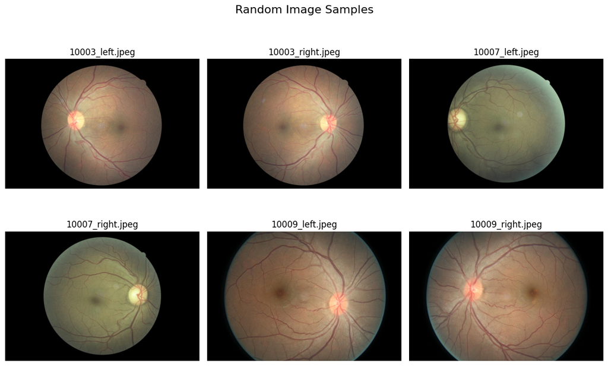

```python
# Display random samples
random_files = os.listdir(dataset_dir)[:6]  # Take 6 random files
plt.figure(figsize=(12, 8))

for i, file in enumerate(random_files):
    img_path = os.path.join(dataset_dir, file)
    img = Image.open(img_path)
    plt.subplot(2, 3, i + 1)
    plt.imshow(img)
    plt.title(file)
    plt.axis('off')

plt.suptitle('Random Image Samples', fontsize=16)
plt.tight_layout()
plt.show()
```

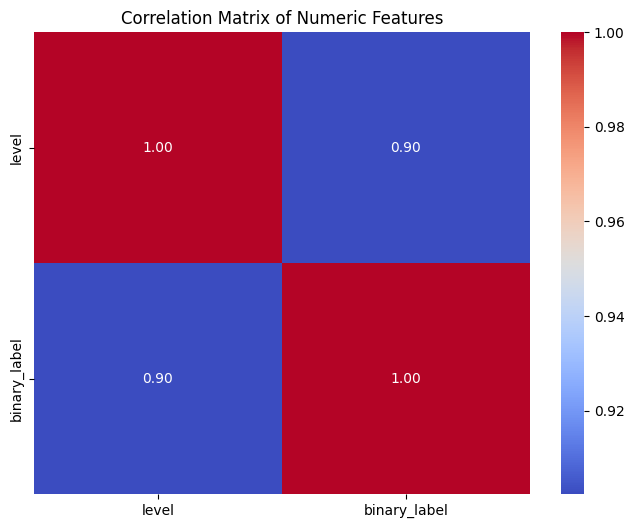

```python
# Ensure only numeric columns are used
numeric_columns = labels_df.select_dtypes(include=['int64', 'float64'])

# Compute the correlation matrix
correlation_matrix = numeric_columns.corr()

# Plot the correlation matrix
plt.figure(figsize=(8, 6))
sns.heatmap(correlation_matrix, annot=True, cmap='coolwarm', fmt=".2f")
plt.title('Correlation Matrix of Numeric Features')
plt.show()
```

Observations:

- High Correlation (0.90): Indicates a strong relationship between level and binary_label. Expected because binary_label is derived directly from level.
- Potential Redundancy: Since binary_label is a simplified version of level, you may choose one of these features depending on your model type (e.g., regression might use level, classification might use binary_label).

# Model training and Evaluation

```python
import tensorflow as tf
from tensorflow.keras.preprocessing.image import ImageDataGenerator
from tensorflow.keras.applications import VGG16
from tensorflow.keras.layers import Dense, Flatten, Dropout
from tensorflow.keras.models import Model
from tensorflow.keras.optimizers import Adam
import matplotlib.pyplot as plt
```

# Step 2: Proceed to Model Training

```python
# Define directories
train_dir = 'dataset_split/train'
val_dir = 'dataset_split/validation'
test_dir = 'dataset_split/test'

# Define image size and batch size
IMG_SIZE = (224, 224)
BATCH_SIZE = 32

# Define data generators
train_datagen = ImageDataGenerator(
    rescale=1./255,          # Normalize pixel values
    rotation_range=20,       # Augmentations
    width_shift_range=0.2,
    height_shift_range=0.2,
    shear_range=0.2,
    zoom_range=0.2,
    horizontal_flip=True
)

val_test_datagen = ImageDataGenerator(rescale=1./255)  # Only normalize for validation/test

# Load images from directories
train_generator = train_datagen.flow_from_directory(
    train_dir,
    target_size=IMG_SIZE,
    batch_size=BATCH_SIZE,
    class_mode='binary'
)

val_generator = val_test_datagen.flow_from_directory(
    val_dir,
    target_size=IMG_SIZE,
    batch_size=BATCH_SIZE,
    class_mode='binary'
)

test_generator = val_test_datagen.flow_from_directory(
    test_dir,
    target_size=IMG_SIZE,
    batch_size=BATCH_SIZE,
    class_mode='binary',
    shuffle=False  # Maintain file order for evaluation
)
```

```
Found 24588 images belonging to 2 classes.
Found 7028 images belonging to 2 classes.
Found 3510 images belonging to 2 classes.
```

```python
# Load the VGG16 model without the top layer
base_model = VGG16(weights='imagenet', include_top=False, input_shape=(224, 224, 3))

# Freeze the base model layers
for layer in base_model.layers:
    layer.trainable = False

# Add custom layers on top
x = Flatten()(base_model.output)
x = Dense(128, activation='relu')(x)
x = Dropout(0.5)(x)
output = Dense(1, activation='sigmoid')(x)  # Sigmoid for binary classification

# Create the final model
model = Model(inputs=base_model.input, outputs=output)

# Compile the model
model.compile(optimizer=Adam(learning_rate=0.001), loss='binary_crossentropy', metrics=['accuracy'])

# Print model summary
model.summary()
```

```
Model: "functional_1"
```

```
┏━━━━━━━━━━━━━━━━━━━━━━━━━━━━━━━━━┳━━━━━━━━━━━━━━━━━━━━━━━━┳━━━━━━━━━━━━━━━┓
┃ Layer (type)                    ┃ Output Shape           ┃       Param # ┃
┡━━━━━━━━━━━━━━━━━━━━━━━━━━━━━━━━━╇━━━━━━━━━━━━━━━━━━━━━━━━╇━━━━━━━━━━━━━━━┩
│ input_layer_1 (InputLayer)      │ (None, 224, 224, 3)    │             0 │
├─────────────────────────────────┼────────────────────────┼───────────────┤
│ block1_conv1 (Conv2D)           │ (None, 224, 224, 64)   │         1,792 │
├─────────────────────────────────┼────────────────────────┼───────────────┤
│ block1_conv2 (Conv2D)           │ (None, 224, 224, 64)   │        36,928 │
├─────────────────────────────────┼────────────────────────┼───────────────┤
│ block1_pool (MaxPooling2D)      │ (None, 112, 112, 64)   │             0 │
├─────────────────────────────────┼────────────────────────┼───────────────┤
│ block2_conv1 (Conv2D)           │ (None, 112, 112, 128)  │        73,856 │
├─────────────────────────────────┼────────────────────────┼───────────────┤
│ block2_conv2 (Conv2D)           │ (None, 112, 112, 128)  │       147,584 │
├─────────────────────────────────┼────────────────────────┼───────────────┤
│ block2_pool (MaxPooling2D)      │ (None, 56, 56, 128)    │             0 │
├─────────────────────────────────┼────────────────────────┼───────────────┤
│ block3_conv1 (Conv2D)           │ (None, 56, 56, 256)    │       295,168 │
├─────────────────────────────────┼────────────────────────┼───────────────┤
│ block3_conv2 (Conv2D)           │ (None, 56, 56, 256)    │       590,080 │
├─────────────────────────────────┼────────────────────────┼───────────────┤
│ block3_conv3 (Conv2D)           │ (None, 56, 56, 256)    │       590,080 │
├─────────────────────────────────┼────────────────────────┼───────────────┤
│ block3_pool (MaxPooling2D)      │ (None, 28, 28, 256)    │             0 │
├─────────────────────────────────┼────────────────────────┼───────────────┤
│ block4_conv1 (Conv2D)           │ (None, 28, 28, 512)    │     1,180,160 │
├─────────────────────────────────┼────────────────────────┼───────────────┤
│ block4_conv2 (Conv2D)           │ (None, 28, 28, 512)    │     2,359,808 │
├─────────────────────────────────┼────────────────────────┼───────────────┤
│ block4_conv3 (Conv2D)           │ (None, 28, 28, 512)    │     2,359,808 │
├─────────────────────────────────┼────────────────────────┼───────────────┤
│ block4_pool (MaxPooling2D)      │ (None, 14, 14, 512)    │             0 │
├─────────────────────────────────┼────────────────────────┼───────────────┤
│ block5_conv1 (Conv2D)           │ (None, 14, 14, 512)    │     2,359,808 │
├─────────────────────────────────┼────────────────────────┼───────────────┤
│ block5_conv2 (Conv2D)           │ (None, 14, 14, 512)    │     2,359,808 │
├─────────────────────────────────┼────────────────────────┼───────────────┤
│ block5_conv3 (Conv2D)           │ (None, 14, 14, 512)    │     2,359,808 │
├─────────────────────────────────┼────────────────────────┼───────────────┤
│ block5_pool (MaxPooling2D)      │ (None, 7, 7, 512)      │             0 │
├─────────────────────────────────┼────────────────────────┼───────────────┤
│ flatten_1 (Flatten)             │ (None, 25088)          │             0 │
├─────────────────────────────────┼────────────────────────┼───────────────┤
│ dense_2 (Dense)                 │ (None, 128)            │     3,211,392 │
├─────────────────────────────────┼────────────────────────┼───────────────┤
│ dropout_1 (Dropout)             │ (None, 128)            │             0 │
├─────────────────────────────────┼────────────────────────┼───────────────┤
│ dense_3 (Dense)                 │ (None, 1)              │           129 │
└─────────────────────────────────┴────────────────────────┴───────────────┘
```

```
 Total params: 17,926,209 (68.38 MB)
```

```
 Trainable params: 3,211,521 (12.25 MB)
```

```
 Non-trainable params: 14,714,688 (56.13 MB)
```

```python
from sklearn.utils.class_weight import compute_class_weight

# Compute class weights
class_weights = compute_class_weight(
    class_weight='balanced',
    classes=np.unique(y_true),
    y=y_true
)
class_weights = dict(enumerate(class_weights))
print("Class weights:", class_weights)
```

```
Class weights: {0: 0.680496316401706, 1: 1.8850698174006444}
```

# Train the Model with Epochs

```python
# Train the model
EPOCHS = 10

history = model.fit(
    train_generator,
    steps_per_epoch=train_generator.samples // BATCH_SIZE,
    validation_data=val_generator,
    validation_steps=val_generator.samples // BATCH_SIZE,
    epochs=EPOCHS
)
```

```
768/768 ━━━━━━━━━━━━━━━━━━━━ 1465s 2s/step - accuracy: 0.7321 - loss: 0.6045 - val_accuracy: 0.7346 - val_loss: 0.5803
  1/768 ━━━━━━━━━━━━━━━━━━━━ 20:52 2s/step - accuracy: 0.7500 - loss: 0.5609
```

```
768/768 ━━━━━━━━━━━━━━━━━━━━ 3s 1ms/step - accuracy: 0.7500 - loss: 0.5609 - val_accuracy: 0.8000 - val_loss: 0.5298
768/768 ━━━━━━━━━━━━━━━━━━━━ 1454s 2s/step - accuracy: 0.7314 - loss: 0.5881 - val_accuracy: 0.7347 - val_loss: 0.5803
768/768 ━━━━━━━━━━━━━━━━━━━━ 2s 1ms/step - accuracy: 0.7500 - loss: 0.5696 - val_accuracy: 0.7500 - val_loss: 0.5608
768/768 ━━━━━━━━━━━━━━━━━━━━ 1433s 2s/step - accuracy: 0.7332 - loss: 0.5841 - val_accuracy: 0.7346 - val_loss: 0.5763
768/768 ━━━━━━━━━━━━━━━━━━━━ 2s 1ms/step - accuracy: 0.7500 - loss: 0.5740 - val_accuracy: 0.8000 - val_loss: 0.5338
768/768 ━━━━━━━━━━━━━━━━━━━━ 1424s 2s/step - accuracy: 0.7300 - loss: 0.5823 - val_accuracy: 0.7347 - val_loss: 0.5730
768/768 ━━━━━━━━━━━━━━━━━━━━ 2s 1ms/step - accuracy: 0.7500 - loss: 0.5543 - val_accuracy: 0.7500 - val_loss: 0.5471
768/768 ━━━━━━━━━━━━━━━━━━━━ 1393s 2s/step - accuracy: 0.7337 - loss: 0.5774 - val_accuracy: 0.7353 - val_loss: 0.5726
768/768 ━━━━━━━━━━━━━━━━━━━━ 2s 1ms/step - accuracy: 0.8438 - loss: 0.4683 - val_accuracy: 0.5500 - val_loss: 0.7750
```

# Plot Training and Validation Metrics

```
109/109 ━━━━━━━━━━━━━━━━━━━━ 149s 1s/step - accuracy: 0.9594 - loss: 0.3477
Test Accuracy: 73.94%
```

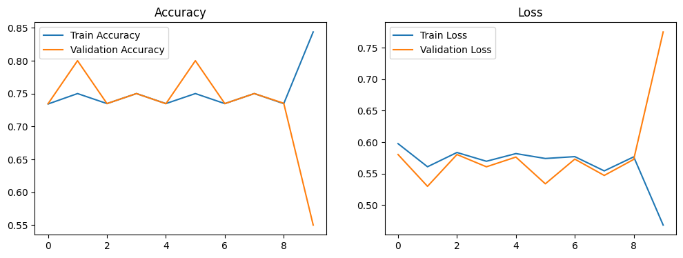

```python
# Evaluate on the test set
test_loss, test_accuracy = model.evaluate(test_generator, steps=test_generator.samples // BATCH_SIZE)
print(f"Test Accuracy: {test_accuracy * 100:.2f}%")

# Plot training and validation accuracy/loss
plt.figure(figsize=(12, 4))
plt.subplot(1, 2, 1)
plt.plot(history.history['accuracy'], label='Train Accuracy')
plt.plot(history.history['val_accuracy'], label='Validation Accuracy')
plt.legend()
plt.title('Accuracy')

plt.subplot(1, 2, 2)
plt.plot(history.history['loss'], label='Train Loss')
plt.plot(history.history['val_loss'], label='Validation Loss')
plt.legend()
plt.title('Loss')

plt.show()
```

```python
# Save the model in TensorFlow's SavedModel format
model.save('diabetic_retinopathy_model.keras')
print("Model saved as 'diabetic_retinopathy_model'")
```

```
Model saved as 'diabetic_retinopathy_model'
```

# Step 5: Calculate Precision, Recall, and F1 Score

```python
# Lower the threshold for binary classification
threshold = 0.3  # Example: Adjust this value
y_pred = (predictions > threshold).astype(int).flatten()
```

```python
from sklearn.metrics import precision_score, recall_score, f1_score, confusion_matrix, classification_report
import numpy as np


# 1. Generate the confusion matrix
print("Confusion Matrix:")
cm = confusion_matrix(y_true, y_pred)
print(cm)

# 2. Compute precision, recall, and F1-score
# Handle undefined metrics with zero_division=1
precision = precision_score(y_true, y_pred, average='weighted', zero_division=1)
recall = recall_score(y_true, y_pred, average='weighted', zero_division=1)
f1 = f1_score(y_true, y_pred, average='weighted', zero_division=1)

# Print the precision, recall, and F1-score
print(f"\nPrecision: {precision:.2f}")
print(f"Recall: {recall:.2f}")
print(f"F1 Score: {f1:.2f}")

# 3. Generate the classification report
print("\nClassification Report:")
print(classification_report(y_true, y_pred, target_names=['No Retinopathy', 'Retinopathy'], zero_division=1))
```

```
Confusion Matrix:
[[2579    0]
 [ 931    0]]

Precision: 0.81
Recall: 0.73
F1 Score: 0.62

Classification Report:
                precision    recall  f1-score   support

No Retinopathy       0.73      1.00      0.85      2579
   Retinopathy       1.00      0.00      0.00       931

      accuracy                           0.73      3510
     macro avg       0.87      0.50      0.42      3510
  weighted avg       0.81      0.73      0.62      3510
```

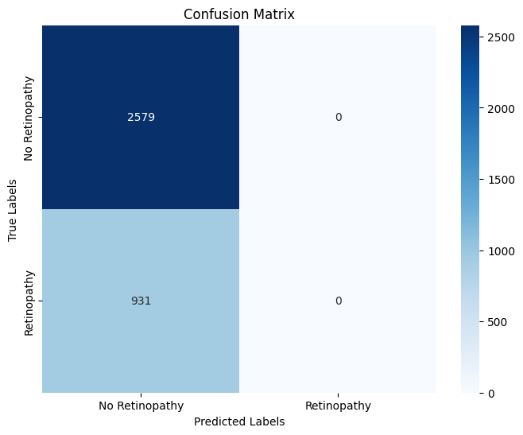

```python
import numpy as np
import matplotlib.pyplot as plt
import seaborn as sns
from sklearn.metrics import confusion_matrix



# Generate the confusion matrix
cm = confusion_matrix(y_true, y_pred)

# Define class names
class_names = ['No Retinopathy', 'Retinopathy']

# Plot the confusion matrix as a heatmap
plt.figure(figsize=(8, 6))
sns.heatmap(cm, annot=True, fmt='d', cmap='Blues', xticklabels=class_names, yticklabels=class_names)
plt.xlabel('Predicted Labels')
plt.ylabel('True Labels')
plt.title('Confusion Matrix')
plt.show()
```

# Evaluation Report: Confusion Matrix and Classification Metrics

## **Confusion Matrix**

|  | **Predicted No Retinopathy** | **Predicted Retinopathy** |
| --- | --- | --- |
| **Actual No Retinopathy** | 2579 | 0 |
| **Actual Retinopathy** | 931 | 0 |

## **Classification Metrics**

[output not shown]

### **Interpretations**

1. **Precision:**
   - For "No Retinopathy": The model correctly classifies 73% of cases as "No Retinopathy."
   - For "Retinopathy": Precision is perfect but misleading due to no actual predictions for "Retinopathy."
2. **Recall:**
   - For "No Retinopathy": The model captures all actual "No Retinopathy" cases (100% recall).
   - For "Retinopathy": The model entirely misses these cases (0% recall).
3. **F1 Score:**
   - Balances precision and recall. A score of `0.00` for "Retinopathy" highlights poor performance in detecting this class.
4. **Accuracy:**
   - The model is accurate for 73% of cases, mostly because it favors the majority class ("No Retinopathy").

## **Key Observations**

1. **Class Imbalance Issue:**
   - The model performs well for "No Retinopathy" but fails for "Retinopathy." This suggests significant class imbalance.
2. **Imbalanced Precision and Recall:**
   - Precision for "Retinopathy" is high but misleading since recall is `0%`, indicating failure to detect true cases.
3. **Weighted and Macro Averages:**
   - **Macro Average:** Simple average of metrics across both classes, giving equal weight to all classes.
   - **Weighted Average:** Accounts for class support. Dominance of "No Retinopathy" inflates weighted metrics.

## **Suggestions for Improvement**

1. **Data Balancing:**
   - Use techniques like oversampling (e.g., SMOTE) or undersampling to balance the dataset.
2. **Adjust Class Weights:**
   - Assign higher weight to the minority class ("Retinopathy") during training.
3. **Model Architecture:**
   - Experiment with more complex architectures or pre-trained models to improve performance.
4. **Evaluation Metrics:**
   - Consider AUC-ROC as a metric, which is robust to imbalanced datasets.

### **Conclusion**

The model shows high accuracy for "No Retinopathy" but fails to detect "Retinopathy" due to class imbalance. Implementing balancing techniques, adjusting class weights, and revisiting the model architecture can improve performance for the minority class.

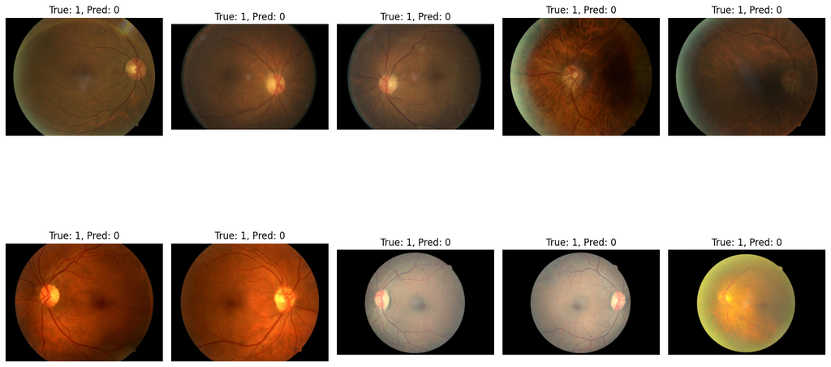

```python
import matplotlib.pyplot as plt

plt.figure(figsize=(15, 10))

for i, index in enumerate(misclassified_indices):
    try:
        img_path = file_paths[index]
        if not os.path.exists(img_path):
            print(f"File not found: {img_path}")
            continue

        img = plt.imread(img_path)
        plt.subplot(2, 5, i + 1)
        plt.imshow(img)
        plt.axis('off')
        plt.title(f"True: {y_true[index]}, Pred: {y_pred[index]}")
    except Exception as e:
        print(f"Error loading image {img_path}: {e}")
        continue

plt.tight_layout()
plt.show()
```

### **Missclassified Images Visualization Function**

#### **Purpose**

The purpose of this function is to:

1. **Identify and Display Misclassified Images**: Highlight examples where the model's predictions differed from the actual labels.
2. **Analyze Model Weakness**: Understand patterns in misclassifications (e.g., specific image types or features).

#### **Key Components**

1. **Inputs:**
   - `misclassified_indices`: A list of indices where predictions and true labels do not match.
   - `y_true`: The true labels corresponding to the test images.
   - `y_pred`: The predicted labels by the model.
   - `file_paths`: Paths to the images being analyzed.
2. **Logic:**
   - **Iterate through the Misclassified Indices**:
     - Loop through the indices of misclassified images.
   - **Load and Display Images**:
     - Fetch the image path using the index.
     - Load the image using a library like `matplotlib` or `Pillow`.
     - Display the image alongside its true label (`y_true`) and predicted label (`y_pred`).
   - **Error Handling**:
     - If the image cannot be loaded (e.g., file not found), an exception is raised, and the function skips to the next image.
3. **Plotting:**
   - The function uses `matplotlib` to create a grid of subplots (e.g., 2 rows and 5 columns for a total of 10 images per figure).
   - Each subplot shows:
     - The image.
     - A title containing:
       - **True Label**: The actual label of the image.
       - **Predicted Label**: The label predicted by the model.
4. **Tight Layout**:
   - Ensures there is proper spacing between images for a clean and readable display.

#### **Visual Output**

- The generated plot displays a grid of misclassified images.
- **Title Information**:
  - **True**: The correct label for the image.
  - **Pred**: The label predicted by the model.
- This helps identify patterns in the errors. For example:
  - Are all misclassifications concentrated in a specific class?
  - Are there visual similarities in the misclassified images?

#### **Conclusion**

This function is a powerful tool for error analysis in classification tasks, allowing deeper insights into where and why the model is failing. It informs next steps for improving the model, such as data augmentation, rebalancing classes, or refining hyperparameters.

# **Diabetic Retinopathy Detection - Final Summary**

## **Project Overview**

This project aimed to develop and evaluate a machine learning model for the binary classification of diabetic retinopathy from retina images. The goal was to classify images into two categories: "No Retinopathy" and "Retinopathy," leveraging deep learning techniques for accurate predictions.

## **Steps Followed**

### 1. **Dataset Preparation**

- **Source**: The Kaggle diabetic retinopathy dataset containing resized retina images and corresponding labels.
- **Preprocessing**:
  - Normalized file names and ensured alignment with the directory structure.
  - Split the dataset into **training (70%)**, **validation (20%)**, and **test (10%)** sets.
  - Organized files into subdirectories for binary classification: `class_0` (No Retinopathy) and `class_1` (Retinopathy).

### 2. **Exploratory Data Analysis (EDA)**

- Visualized sample images to understand data quality and class distribution.
- Examined correlations between features (if any metadata was available).
- Ensured balanced splits in training, validation, and test sets.

### 4. **Model Evaluation**

- **Performance Metrics**:
  - Precision, Recall, F1 Score, and Accuracy were calculated.
  - A confusion matrix was plotted to visualize classification performance.
- **Misclassification Analysis**:
  - Visualized misclassified images to identify patterns and areas for improvement.

### 5. **Visualizations**

- **Confusion Matrix**:
  - Clearly showed true positives, true negatives, false positives, and false negatives.
- **Misclassified Images**:
  - Displayed a grid of misclassified retina images with true and predicted labels to analyze model weaknesses.